# Analyzing Cabinet Turnover

Aaron Gould, Lila Craveiro, Danielle Freshwaters

12/18/2019

## Cabinet Turnover Data

**Question:** We will be analyzing the data set **cabinet_turnover** from the **fivethirtyeight** package. This data set includes variables taken from 7 different presidencies, from Jimmy Carter to Donald Trump, summarizing turnover in each of their cabinets. It was collected from the Federal Government Website News Reports. Our question is: **What factors effect the length of an appointee’s cabinet tenure?** We will be evaluating how *position* (the cabinet position), *president* (the sitting president), and a variable of our own creation *days_into_term_start* (number of days into the administration the appointee started) affect *length_proportion* (another variable we created that gives us the proportion of *length* to the total number of days an appointee could have served).

### Response Variable: *length*

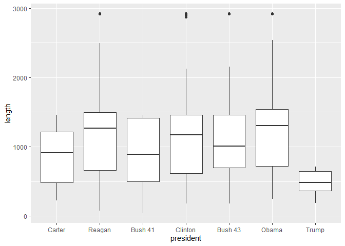

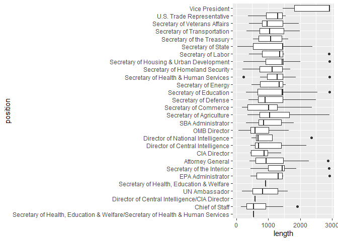

Clearly, there are too many cabinet positions to be legible, so we are picking these few to analyze:

Secretary of Homeland Security  
EPA Administrator  
Secretary of Health & Human Services  
Secretary of Education  
Secretary of Defense  
Secretary of Labor  
Chief of Staff

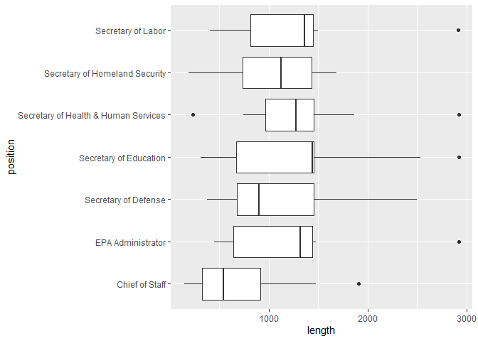

New variable *days_into_term_start*: the number of days into the president’s term that the appointee started

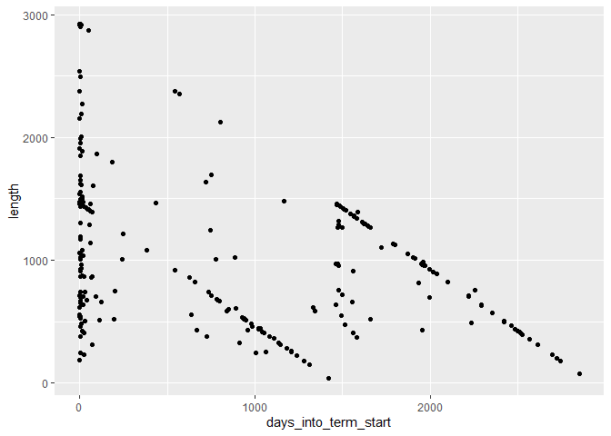

New variable *length_proportion*: the proportion of *length* to the total number of days an appointee could have served. For example…

### Response Variable: *length_proportion*

| president | appointee | admin_total_days | length_proportion |
| --- | --- | --- | --- |
| Carter | Bert Lance | 1460 | 0.1680384 |
| Carter | Brock Adams | 1460 | 0.6236264 |
| Carter | Joseph Califano Jr. | 1460 | 0.6327373 |
| Carter | Patricia Harris | 1460 | 0.6332418 |
| Carter | W. Michael Blumenthal | 1460 | 0.6339286 |
| Carter | Griffin Bell | 1460 | 0.6414315 |
| Carter | Robert Strauss | 1460 | 0.6258993 |
| Carter | James Schlesinger | 1460 | 0.5923870 |
| Carter | Andrew Young | 1460 | 0.6666667 |
| Carter | Juanita Kreps | 1460 | 0.6943681 |

[output cut: 302 more lines]

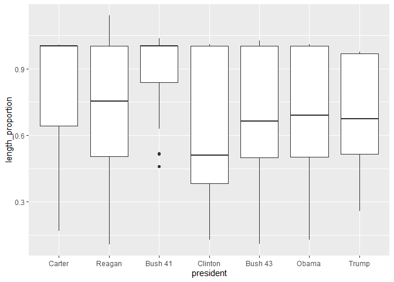

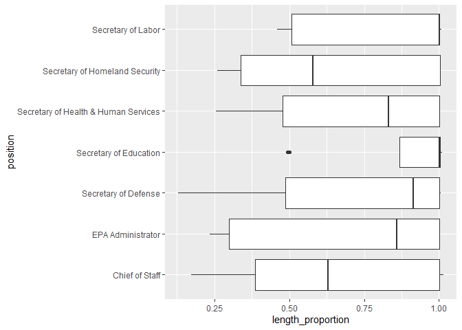

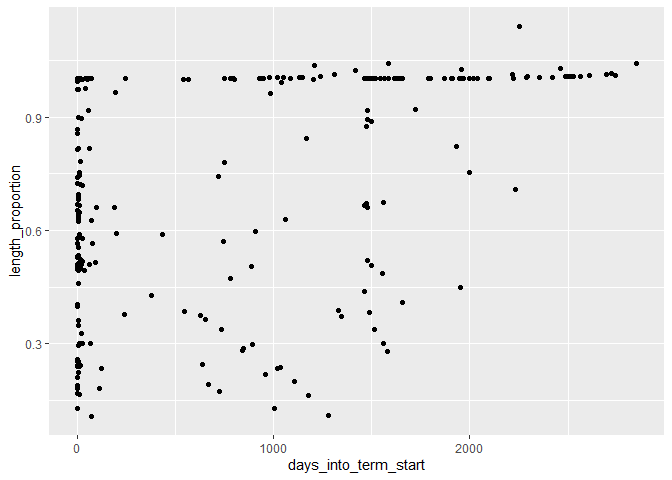

### Models

| term | estimate | std_error | statistic | p_value | lower_ci | upper_ci |
| --- | --- | --- | --- | --- | --- | --- |
| intercept | 0.859 | 0.050 | 17.196 | 0.000 | 0.761 | 0.957 |
| chronological_presidentReagan | -0.157 | 0.065 | -2.434 | 0.016 | -0.284 | -0.030 |
| chronological_presidentBush 41 | 0.043 | 0.072 | 0.593 | 0.554 | -0.100 | 0.185 |
| chronological_presidentClinton | -0.212 | 0.065 | -3.288 | 0.001 | -0.340 | -0.085 |
| chronological_presidentBush 43 | -0.163 | 0.063 | -2.592 | 0.010 | -0.287 | -0.039 |
| chronological_presidentObama | -0.165 | 0.064 | -2.600 | 0.010 | -0.291 | -0.040 |
| chronological_presidentTrump | -0.180 | 0.097 | -1.861 | 0.064 | -0.370 | 0.010 |

Intercept: The average *length_proportion* of an appointee under the Carter administration  
chronological_presidentReagan coefficient: The difference in *length_proportion* for an appointee between Reagan and Carter on average

| term | estimate | std_error | statistic | p_value | lower_ci | upper_ci |
| --- | --- | --- | --- | --- | --- | --- |
| intercept | 0.629 | 0.067 | 9.382 | 0.000 | 0.495 | 0.763 |
| positionEPA Administrator | 0.062 | 0.111 | 0.562 | 0.576 | -0.159 | 0.284 |
| positionSecretary of Defense | 0.117 | 0.111 | 1.049 | 0.298 | -0.105 | 0.338 |
| positionSecretary of Education | 0.238 | 0.122 | 1.942 | 0.056 | -0.006 | 0.482 |
| positionSecretary of Health & Human Services | 0.093 | 0.118 | 0.792 | 0.431 | -0.142 | 0.329 |
| positionSecretary of Homeland Security | 0.007 | 0.153 | 0.049 | 0.961 | -0.297 | 0.312 |
| positionSecretary of Labor | 0.158 | 0.114 | 1.383 | 0.171 | -0.070 | 0.386 |

Intercept: The average *length_proportion* of a Chief of Staff appointee  
positionEPAadministrator: The difference in *length_proportion* between Chief of Staff and EPA Administrator on average

| term | estimate | std.error | statistic | p.value |
| --- | --- | --- | --- | --- |
| (Intercept) | 60.81235540 | 2.165063981 | 28.088018 | 1.959870e-83 |
| days_into_term_start | 0.01538928 | 0.001888219 | 8.150157 | 1.222273e-14 |

Intercept: The average *length_proportion* as a percentage for all cabinet positions under all presidents  
The estimate for the *days_into_term_start* coefficient is about 0.015 (as a percent, rather than a decimal). The p-value is so small, it can be considered 0. This means that there is a relationship between *days_into_term_start* and *length_proportion* although it is a weak relationship.

| term | estimate | std_error | statistic | p_value | lower_ci | upper_ci |
| --- | --- | --- | --- | --- | --- | --- |
| intercept | 0.804 | 0.245 | 3.279 | 0.002 | 0.307 | 1.300 |
| chronological_presidentReagan | -0.116 | 0.300 | -0.386 | 0.702 | -0.724 | 0.492 |
| chronological_presidentBush 41 | -0.014 | 0.316 | -0.045 | 0.965 | -0.655 | 0.626 |
| chronological_presidentClinton | -0.300 | 0.300 | -1.000 | 0.324 | -0.908 | 0.307 |
| chronological_presidentBush 43 | 0.025 | 0.347 | 0.072 | 0.943 | -0.677 | 0.727 |
| chronological_presidentObama | -0.407 | 0.300 | -1.356 | 0.183 | -1.015 | 0.201 |
| chronological_presidentTrump | -0.192 | 0.347 | -0.553 | 0.584 | -0.893 | 0.510 |
| positionEPA Administrator | 0.198 | 0.425 | 0.466 | 0.644 | -0.662 | 1.057 |
| positionSecretary of Defense | 0.198 | 0.425 | 0.466 | 0.644 | -0.662 | 1.057 |
| positionSecretary of Education | 0.201 | 0.425 | 0.474 | 0.638 | -0.658 | 1.061 |

[output cut: 32 more lines]

Intercept: The average *length_proprtion* for a Chief of Staff appointee under the Carter administration  
chronological_presidentReagan:positionEPA Administrator: The average change in *length_proportion* between a Chief of Staff appointee and EPA Administrator from Carter to Reagan

### Hypothesis Tests

*president* vs. *length_proportion*

$H_0$: All coefficients are equal to 0, there is no relationship between *president* and *length_proportion*

$H_a$: At least one coefficient is not equal to 0, there is a relationship between *president* and *length_proportion*

| res.df | rss | df | sumsq | statistic | p.value |
| --- | --- | --- | --- | --- | --- |
| 281 | 24.62515 | NA | NA | NA | NA |
| 275 | 22.64224 | 6 | 1.98291 | 4.013885 | 0.0007160622 |

The p-value is about 0.0007, significantly less than 0.05. This means that we can reject the null hypothesis and there is a strong relationship between *president* and *length_proportion*.

Interaction between *president* and *position*

| res.df | rss | df | sumsq | statistic | p.value |
| --- | --- | --- | --- | --- | --- |
| 67 | 6.256948 | NA | NA | NA | NA |
| 38 | 4.565619 | 29 | 1.691328 | 0.4854157 | 0.9766396 |

The p-value here is very high, about 0.98. This means that we cannot reject the null hypothesis - there could be no interaction between *president* and *position*.